# Why R?

Software carpentry - R workshop

07/04/2025

# working with biological data with R workshop

Workshop links - https://anatmela.github.io/20250407-RWorkshop/

Share document - https://etherpad.opendev.org/p/rworkshop20250407

Carpentries code of conduct - https://docs.carpentries.org/policies/coc/

R

Rstudio

# Software carpentry - code of conduct

https://docs.carpentries.org/policies/coc/

# Software carpentry - The ‘sticky notes’ system

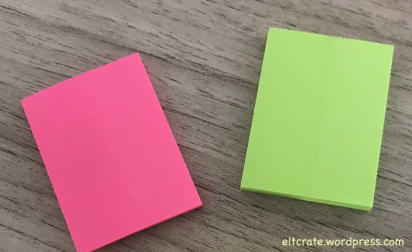

# What is R good for?

- Reproduicibility
- Efficiency
- Flexibility
- Systematic
- Collabortive

# What can I do with R?

- Data manipulation (filter, sort, etc)
- Data visualisation
- Statistics

# Cautionary tale…

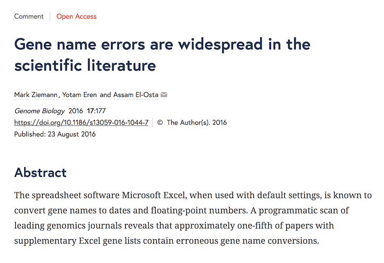

# What else can I do with R?

- Complex plots and graphs
- Work with biological sequence data and reference data (e.g. Bioconductor)

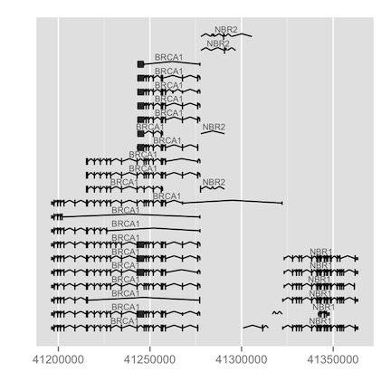

http://www.sthda.com/english/wiki/ggbio-visualize-genomic-data

# What else can I do with R?

- Complex plots and graphs
- Work with biological data (e.g. Bioconductor)
- Work with Chemical data (e.g. ChemmineR)

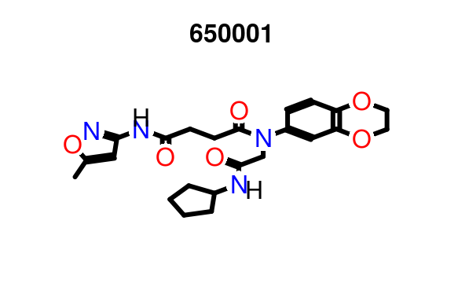

https://www.bioconductor.org/packages/devel/bioc/vignettes/ChemmineR/inst/doc/ChemmineR.html

# What else can I do with R?

- Complex plots and graphs
- Work with biological data (e.g. Bioconductor)
- Work with Chemical data (e.g. ChemmineR)
- Work with Economical data
- Create apps (Shiny)
- Interact with other software and different formats
- Write reports and presentations
- Statistical learning
- Web scraping
- Send emails
- SO MUCH MORE…

# RXKCD

```r
xkcd <- getXKCD('1168')
```

[figure not shown]

# working with biological data with R workshop

Workshop links - https://anatmela.github.io/20250407-RWorkshop/

Share document - https://etherpad.opendev.org/p/rworkshop20250407

Carpentries code of conduct - https://docs.carpentries.org/policies/coc/

R

Rstudio

# Data types

The type of data you are trying to interpret will determine which plot type you should use and which statistical tests may be informative.

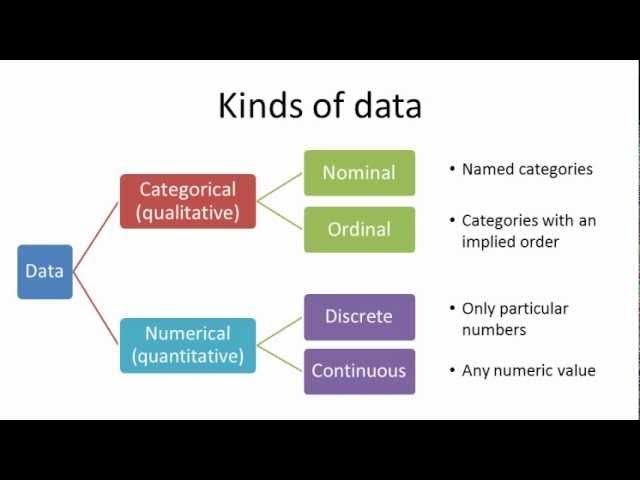

https://youtu.be/7bsNWq2A5gI

# ggplot

create graphics from your data by adding layers

ggplot(data, mapping = aes()) + # initialise

geom_<geom name>() + # actual type of plot (can have > 1)

scale_<which scale>_<type of data> # optional (can set for each scale in aes)  
other layers which can be added (used for further refinement of the plot):  
- facets  
- labs  
- theme  
- guides  
- annotate